# GHFC Co-op Reopening Checkin Desk Analysis

Josh Hadro

2020-06-16

## Analysis of Greene Hill Co-op by Check-in Type

The Co-op has recently reinstated its check-in procedure. As part of the IT group’s work to revise the check-in application, we’re able to capture a lot more usable data for analysis of who is coming into the store and when.

Unfortunately, this data practice has only been in place for 12 days, but I’m able to provide a preliminary analysis based on what we have so far.

(See the previous report [(“GHFC Co-op Checkin Desk Analysis”)](https://hadro.github.io/ghfc/ghfc_psfc_report) for a view into the data we were able analyze from mid-March 2019 through mid-March 2020, when the previous iteration of the check-in desk was in operation.)

N.B.: this data reflects only what was captured – put another way, if people did not check in at the check-in desk or mis-entered their data, then those statistics would not, by definition, be captured here. That said, I have no reason to believe the figures here are under-representative in any significant way. Moreover, the improved UX of the new checkin desk makes it easy to check in, and I’m confident in the few days of data we have.

## Shoppers per day

The following figure shows the number of shoppers for every day for the 12 days starting June 05. Each bar represents the total number of check-ins on a single day.

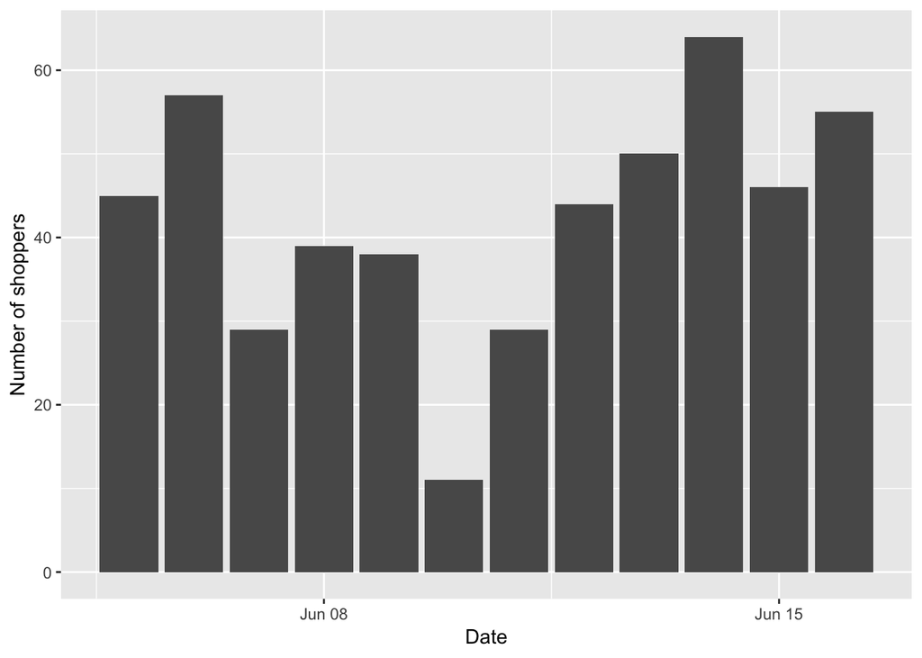

### Shoppers per week, by type

While there are only 12 days of data available, the revised check-in system allows for more granular faceting. For example, we now capture more specifically what type of visitor each check-in is associated with.

There are four possible values:

- GHFC (Greene Hill Food Co-op member)
- PSFC (Park Slope Food Co-op member)
- Trial member
- Visitor

In the figure that follows, you can see that the number of GHFC, PSFC, and visitor shoppers increased over the last week. Meanwhile, the percentages indicate the percent of that type of shopper during that week. So while the raw number of GHFC shoppers went up over the past week, other categories increased more so GHFC overall accounted for a smaller proportion of all shopper types.

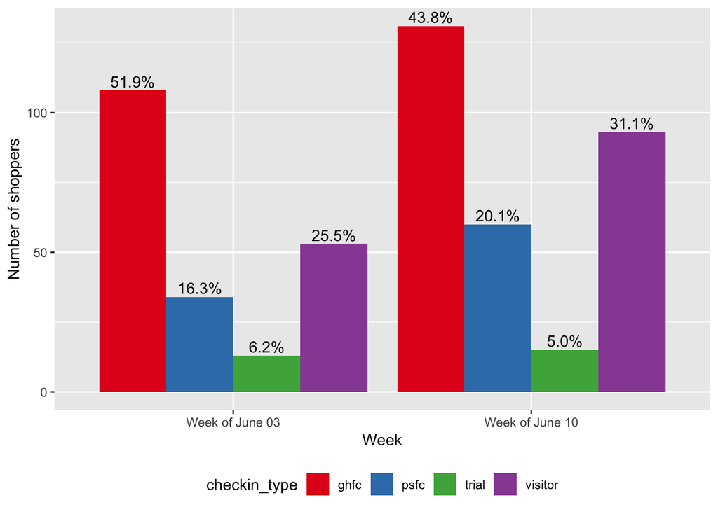

To give you a sense of relative daily numbers, the figure below shows the total shoppers per day broken out by each of these four check-in types.

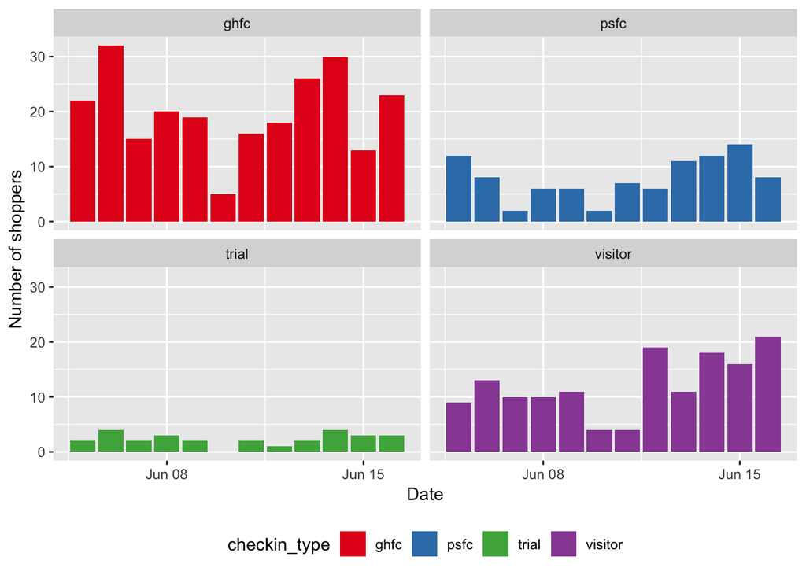

That’s it for now – but as always, please let me know if there’s a question you’d like to investigate based on this data or any other data, and I’ll be happy to take a look.